# Biodiversity with different organic carbon

Antone Jung

April 10, 2025

# Goals

Run an analysis on the within-sample biodiversity of the samples in our project.

## Outputs

*This is an exciting analysis!!! We finally get to answer one of our scientific questions!*

1. Calculated biodiversity measures (Hill numbers) across every sample.
2. Figures to include in our scientific paper that visualize the data as it relates to the scientific question.
3. Statistical tests conveying the measured and quantified changes and patterns in biodiversity.

# Scientific Question

## Question & Hypotheses

How is microbial biodiversity modified across a soil organic carbon gradient?

- *Null Hypothesis:* Soil microbial biodiversity (*e.g.* simpson) does not vary along an organic carbon gradient.
- *Alternative Hypothesis:* Soil microbial biodiversity (*e.g.* simpson) will increase as organic carbon increases. There is a direct relationship between organic carbon and diversity weighted on dominant species.

*Let’s get to calculating Biodiversity!*

# Set up the Environment

## Set the seed

```r
set.seed(10202005)
```

## Load Packages & Colors

```r
# install packages for stats
#install.packages("rstatix")
#install.packages("ggpubr")

pacman::p_load(tidyverse, devtools, patchwork, iNEXT, phyloseq,
               # packages for stats
               ggpubr, rstatix, install = FALSE)

# Load in colors for plotting
source("code/colors.R")
```

## Load in Data

```r
load("data/04_PhylogeneticTree/archaeal_rooted_physeq.RData")

# take a look at it!
archaeal_rooted_physeq
```

```
## phyloseq-class experiment-level object
## otu_table()   OTU Table:         [ 9336 taxa and 36 samples ]
## sample_data() Sample Data:       [ 36 samples by 9 sample variables ]
## tax_table()   Taxonomy Table:    [ 9336 taxa by 9 taxonomic ranks ]
## phy_tree()    Phylogenetic Tree: [ 9336 tips and 9335 internal nodes ]
```

```r
# Intuition check on seq depth
min(sample_sums(archaeal_rooted_physeq))
```

```
## [1] 9539
```

```r
# Make a metadata dataframe
metadata_df <-
  archaeal_rooted_physeq %>%
  sample_data() %>%
  data.frame()

# view of it
glimpse(metadata_df)
```

```
## Rows: 36
## Columns: 9
## $ scientific_name   <chr> "soil metagenome", "rhizosphere metagenome", "rhizos…
## $ experiment_title  <chr> "Illumina MiSeq sequencing: 16S amplicon of CS sampl…
## $ soil_type         <chr> "Sand", "Sand", "Sand", "Florence", "Lansing", "Pend…
## $ Sample_or_Control <lgl> TRUE, TRUE, TRUE, TRUE, TRUE, TRUE, TRUE, TRUE, TRUE…
## $ denoisedF         <dbl> 34565, 28298, 33520, 28515, 21088, 20608, 21745, 429…
## $ denoisedR         <dbl> 34534, 28313, 33560, 28548, 21168, 20591, 21812, 430…
## $ merged            <dbl> 34131, 27814, 32974, 26091, 19702, 18187, 19362, 346…
## $ nochim            <dbl> 32332, 25728, 30590, 25822, 19242, 18027, 18705, 341…
## $ num_ASVs          <dbl> 240, 170, 204, 767, 624, 784, 843, 1443, 1198, 927, …
```

# Biodiversity Hill Numbers with iNEXT

```r
# prepare the input data
# Species in rows and the samples in columns
iNEXT_input_df <-
  archaeal_rooted_physeq %>%
  otu_table() %>%
  data.frame()

# Inpect
dim(iNEXT_input_df)
```

```
## [1] 9336   36
```

```r
iNEXT_input_df[1:5, 1:5]
```

```
##          SRR12183139 SRR12183147 SRR12183158 SRR12183176 SRR12183187
## ASV_2420           0          15           3           0           0
## ASV_8817           0           0           0           0           0
## ASV_8865           0           0           0           0           0
## ASV_8742           0           0           0           0           0
## ASV_9565           0           0           0           0           0
```

```r
# Run iNEXT
# Remember to set the seed!
# ASVs in ROWs, samples in COLUMNS
iNEXT_data <- iNEXT(iNEXT_input_df,
                    q = c(0, 1, 2),
                    datatype = "abundance")
```

```r
# Inspect
str(iNEXT_data)
```

```
## List of 3
##  $ DataInfo:'data.frame':    36 obs. of  14 variables:
##   ..$ Assemblage: chr [1:36] "SRR12183139" "SRR12183147" "SRR12183158" "SRR12183176" ...
##   ..$ n         : num [1:36] 30668 25606 30370 24779 18647 ...
##   ..$ S.obs     : num [1:36] 216 162 191 746 617 ...
##   ..$ SC        : num [1:36] 1 1 1 1 1 1 1 1 1 1 ...
##   ..$ f1        : num [1:36] 0 0 0 0 0 0 0 0 0 1 ...
##   ..$ f2        : num [1:36] 4 4 1 14 9 14 21 33 27 22 ...
##   ..$ f3        : num [1:36] 3 6 6 28 15 34 46 56 69 28 ...
##   ..$ f4        : num [1:36] 5 10 7 43 31 47 56 59 63 32 ...
##   ..$ f5        : num [1:36] 9 3 3 49 41 65 78 66 57 35 ...
##   ..$ f6        : num [1:36] 4 6 7 46 39 54 59 69 77 21 ...
##   ..$ f7        : num [1:36] 8 3 4 44 45 57 49 76 52 39 ...
##   ..$ f8        : num [1:36] 6 11 6 52 30 41 47 62 50 32 ...
##   ..$ f9        : num [1:36] 4 4 11 35 38 30 37 58 40 51 ...
##   ..$ f10       : num [1:36] 5 3 4 37 27 38 39 52 43 31 ...
##  $ iNextEst:List of 2
##   ..$ size_based    :'data.frame':   4320 obs. of  10 variables:
##   .. ..$ Assemblage: chr [1:4320] "SRR12183139" "SRR12183139" "SRR12183139" "SRR12183139" ...
##   .. ..$ m         : num [1:4320] 1 1704 3408 5112 6815 ...
##   .. ..$ Method    : chr [1:4320] "Rarefaction" "Rarefaction" "Rarefaction" "Rarefaction" ...
##   .. ..$ Order.q   : num [1:4320] 0 0 0 0 0 0 0 0 0 0 ...
##   .. ..$ qD        : num [1:4320] 1 158 184 196 203 ...
##   .. ..$ qD.LCL    : num [1:4320] 1 157 182 194 200 ...
##   .. ..$ qD.UCL    : num [1:4320] 1 160 186 198 205 ...
##   .. ..$ SC        : num [1:4320] 0.0377 0.9762 0.9904 0.9949 0.9969 ...
##   .. ..$ SC.LCL    : num [1:4320] 0.0368 0.9756 0.99 0.9946 0.9967 ...
##   .. ..$ SC.UCL    : num [1:4320] 0.0387 0.9769 0.9909 0.9952 0.9972 ...
##   ..$ coverage_based:'data.frame':   2157 obs. of  8 variables:
##   .. ..$ Assemblage: chr [1:2157] "SRR12183139" "SRR12183139" "SRR12183139" "SRR12183139" ...
##   .. ..$ SC        : num [1:2157] 0.0377 0.9762 0.9904 0.9949 0.9969 ...
##   .. ..$ m         : num [1:2157] 1 1704 3408 5112 6815 ...
##   .. ..$ Method    : chr [1:2157] "Rarefaction" "Rarefaction" "Rarefaction" "Rarefaction" ...
##   .. ..$ Order.q   : num [1:2157] 0 0 0 0 0 0 0 0 0 0 ...
##   .. ..$ qD        : num [1:2157] 1 158 184 196 203 ...
##   .. ..$ qD.LCL    : num [1:2157] 0.986 156.112 181.364 193.282 200.1 ...
##   .. ..$ qD.UCL    : num [1:2157] 1.01 160.8 186.71 198.67 205.41 ...
##  $ AsyEst  :'data.frame':    108 obs. of  7 variables:
##   ..$ Assemblage: chr [1:108] "SRR12183139" "SRR12183139" "SRR12183139" "SRR12183147" ...
##   ..$ Diversity : chr [1:108] "Species richness" "Shannon diversity" "Simpson diversity" "Species richness" ...
##   ..$ Observed  : num [1:108] 216 58.5 26.5 162 29.5 ...
##   ..$ Estimator : num [1:108] 216 58.7 26.5 162 29.6 ...
##   ..$ s.e.      : num [1:108] 2.366 0.443 0.32 3.01 0.306 ...
##   ..$ LCL       : num [1:108] 216 57.8 25.9 162 29 ...
##   ..$ UCL       : num [1:108] 220.6 59.5 27.1 167.9 30.2 ...
##  - attr(*, "class")= chr "iNEXT"
```

```r
typeof(iNEXT_data)
```

```
## [1] "list"
```

# Rarefaction Curves

## `ggiNEXT` Rarefaction Curves

```r
# Prepare Colors
color_df <-
  iNEXT_input_df %>%
  colnames() %>%
  data.frame()
# Check
head(color_df)
```

```
##             .
## 1 SRR12183139
## 2 SRR12183147
## 3 SRR12183158
## 4 SRR12183176
## 5 SRR12183187
## 6 SRR12183204
```

```r
# Rename the column
colnames(color_df)[1] <- "names"
# Check
head(color_df)
```

```
##         names
## 1 SRR12183139
## 2 SRR12183147
## 3 SRR12183158
## 4 SRR12183176
## 5 SRR12183187
## 6 SRR12183204
```

```r
metadata_w_Names_df <- rownames_to_column(metadata_df, var = "sample_names")
metadata_dupeColNames_df <- metadata_w_Names_df %>% mutate(., "names" = sample_names)
metadata_dupeNames_df <- column_to_rownames(metadata_dupeColNames_df, var = "sample_names")

metadata_full_df <- metadata_dupeNames_df %>%
  mutate(., "TC_percent" = ifelse(soil_type == "Lansing", 2.25, 0)) %>%
  mutate(., "TC_percent" = ifelse(soil_type == "Florence", 0.73, TC_percent)) %>%
  mutate(., "TC_percent" = ifelse(soil_type == "Pendelton", 1, TC_percent))

# Make a helper dataframe for plotting with colors
iNEXT_color_df <-
  color_df %>%
  # Merge with metadata
  left_join(metadata_dupeNames_df, by = "names") %>%
  # Merge with colors for plotting with ggiNEXT
  left_join(data.frame(soil_colors = soil_colors,
            soil_type = names(soil_colors)),
            by = "soil_type")

head(iNEXT_color_df)
```

```
##         names        scientific_name
## 1 SRR12183139        soil metagenome
## 2 SRR12183147 rhizosphere metagenome
## 3 SRR12183158 rhizosphere metagenome
## 4 SRR12183176        soil metagenome
## 5 SRR12183187        soil metagenome
## 6 SRR12183204        soil metagenome
##                                                                                                                                                                        experiment_title
## 1      Illumina MiSeq sequencing: 16S amplicon of CS sample from mesocosm with Sand soil and Gv Experiment 1. Samples collected 81 days after soil in-growth cores inserted in mesocosm
## 2      Illumina MiSeq sequencing: 16S amplicon of RT sample from mesocosm with Sand soil and Gv Experiment 1. Samples collected 81 days after soil in-growth cores inserted in mesocosm
## 3      Illumina MiSeq sequencing: 16S amplicon of RT sample from mesocosm with Sand soil and Gv Experiment 1. Samples collected 81 days after soil in-growth cores inserted in mesocosm
## 4  Illumina MiSeq sequencing: 16S amplicon of CH sample from mesocosm with Florence soil and Gv Experiment 1. Samples collected 81 days after soil in-growth cores inserted in mesocosm
## 5   Illumina MiSeq sequencing: 16S amplicon of CH sample from mesocosm with Lansing soil and Gv Experiment 1. Samples collected 81 days after soil in-growth cores inserted in mesocosm
## 6 Illumina MiSeq sequencing: 16S amplicon of CH sample from mesocosm with Pendelton soil and Gv Experiment 1. Samples collected 81 days after soil in-growth cores inserted in mesocosm
##   soil_type Sample_or_Control denoisedF denoisedR merged nochim num_ASVs
## 1      Sand              TRUE     34565     34534  34131  32332      240
## 2      Sand              TRUE     28298     28313  27814  25728      170
## 3      Sand              TRUE     33520     33560  32974  30590      204
## 4  Florence              TRUE     28515     28548  26091  25822      767
## 5   Lansing              TRUE     21088     21168  19702  19242      624
## 6 Pendelton              TRUE     20608     20591  18187  18027      784
##   soil_colors
## 1     #D9CC3C
## 2     #D9CC3C
## 3     #D9CC3C
## 4     #A0E0BA
## 5 dodgerblue4
## 6 dodgerblue2
```

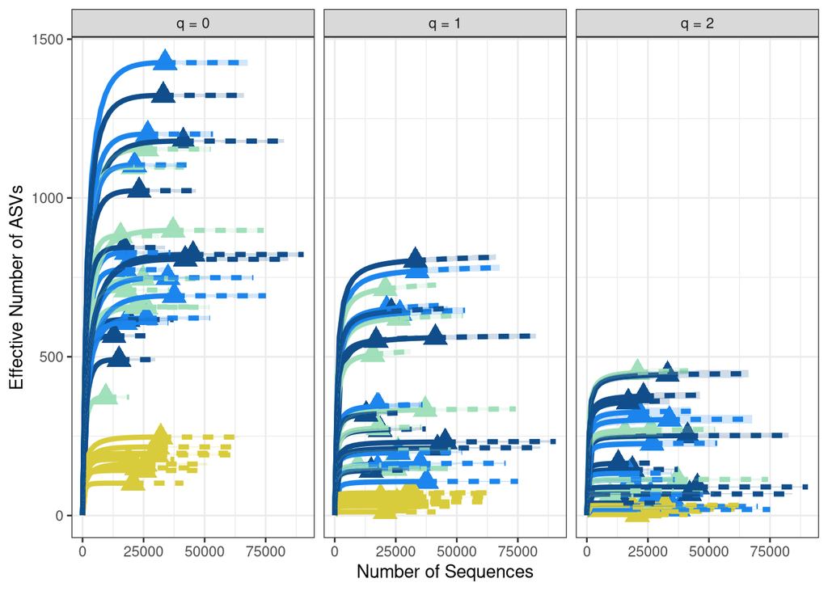

```r
ggiNEXT(iNEXT_data, type = 1, facet.var = "Order.q") +
  scale_color_manual(values = iNEXT_color_df$soil_colors) +
  scale_fill_manual(values = iNEXT_color_df$soil_colors) +
  scale_shape_manual(values = base::rep(17, nsamples(archaeal_rooted_physeq))) +
  theme_bw() +
  theme(legend.position = "none") +
  labs(y = "Effective Number of ASVs", x = "Number of Sequences")
```

## Manual Rarefaction Curves

```r
str(iNEXT_data)
```

```
## List of 3
##  $ DataInfo:'data.frame':    36 obs. of  14 variables:
##   ..$ Assemblage: chr [1:36] "SRR12183139" "SRR12183147" "SRR12183158" "SRR12183176" ...
##   ..$ n         : num [1:36] 30668 25606 30370 24779 18647 ...
##   ..$ S.obs     : num [1:36] 216 162 191 746 617 ...
##   ..$ SC        : num [1:36] 1 1 1 1 1 1 1 1 1 1 ...
##   ..$ f1        : num [1:36] 0 0 0 0 0 0 0 0 0 1 ...
##   ..$ f2        : num [1:36] 4 4 1 14 9 14 21 33 27 22 ...
##   ..$ f3        : num [1:36] 3 6 6 28 15 34 46 56 69 28 ...
##   ..$ f4        : num [1:36] 5 10 7 43 31 47 56 59 63 32 ...
##   ..$ f5        : num [1:36] 9 3 3 49 41 65 78 66 57 35 ...
##   ..$ f6        : num [1:36] 4 6 7 46 39 54 59 69 77 21 ...
##   ..$ f7        : num [1:36] 8 3 4 44 45 57 49 76 52 39 ...
##   ..$ f8        : num [1:36] 6 11 6 52 30 41 47 62 50 32 ...
##   ..$ f9        : num [1:36] 4 4 11 35 38 30 37 58 40 51 ...
##   ..$ f10       : num [1:36] 5 3 4 37 27 38 39 52 43 31 ...
##  $ iNextEst:List of 2
##   ..$ size_based    :'data.frame':   4320 obs. of  10 variables:
##   .. ..$ Assemblage: chr [1:4320] "SRR12183139" "SRR12183139" "SRR12183139" "SRR12183139" ...
##   .. ..$ m         : num [1:4320] 1 1704 3408 5112 6815 ...
##   .. ..$ Method    : chr [1:4320] "Rarefaction" "Rarefaction" "Rarefaction" "Rarefaction" ...
##   .. ..$ Order.q   : num [1:4320] 0 0 0 0 0 0 0 0 0 0 ...
##   .. ..$ qD        : num [1:4320] 1 158 184 196 203 ...
##   .. ..$ qD.LCL    : num [1:4320] 1 157 182 194 200 ...
##   .. ..$ qD.UCL    : num [1:4320] 1 160 186 198 205 ...
##   .. ..$ SC        : num [1:4320] 0.0377 0.9762 0.9904 0.9949 0.9969 ...
##   .. ..$ SC.LCL    : num [1:4320] 0.0368 0.9756 0.99 0.9946 0.9967 ...
##   .. ..$ SC.UCL    : num [1:4320] 0.0387 0.9769 0.9909 0.9952 0.9972 ...
##   ..$ coverage_based:'data.frame':   2157 obs. of  8 variables:
##   .. ..$ Assemblage: chr [1:2157] "SRR12183139" "SRR12183139" "SRR12183139" "SRR12183139" ...
##   .. ..$ SC        : num [1:2157] 0.0377 0.9762 0.9904 0.9949 0.9969 ...
##   .. ..$ m         : num [1:2157] 1 1704 3408 5112 6815 ...
##   .. ..$ Method    : chr [1:2157] "Rarefaction" "Rarefaction" "Rarefaction" "Rarefaction" ...
##   .. ..$ Order.q   : num [1:2157] 0 0 0 0 0 0 0 0 0 0 ...
##   .. ..$ qD        : num [1:2157] 1 158 184 196 203 ...
##   .. ..$ qD.LCL    : num [1:2157] 0.986 156.112 181.364 193.282 200.1 ...
##   .. ..$ qD.UCL    : num [1:2157] 1.01 160.8 186.71 198.67 205.41 ...
##  $ AsyEst  :'data.frame':    108 obs. of  7 variables:
##   ..$ Assemblage: chr [1:108] "SRR12183139" "SRR12183139" "SRR12183139" "SRR12183147" ...
##   ..$ Diversity : chr [1:108] "Species richness" "Shannon diversity" "Simpson diversity" "Species richness" ...
##   ..$ Observed  : num [1:108] 216 58.5 26.5 162 29.5 ...
##   ..$ Estimator : num [1:108] 216 58.7 26.5 162 29.6 ...
##   ..$ s.e.      : num [1:108] 2.366 0.443 0.32 3.01 0.306 ...
##   ..$ LCL       : num [1:108] 216 57.8 25.9 162 29 ...
##   ..$ UCL       : num [1:108] 220.6 59.5 27.1 167.9 30.2 ...
##  - attr(*, "class")= chr "iNEXT"
```

```r
iNEXT_manual_df <-
  iNEXT_data$iNextEst$size_based %>%
  dplyr::rename(names = Assemblage) %>%
  left_join(., metadata_full_df, by = "names") %>%
  mutate(soil_type = factor(soil_type, levels = c("Lansing",
                                              "Pendelton",
                                              "Sand",
                                              "Florence")))

# Inspection
dim(iNEXT_manual_df)
```

```
## [1] 4320   20
```

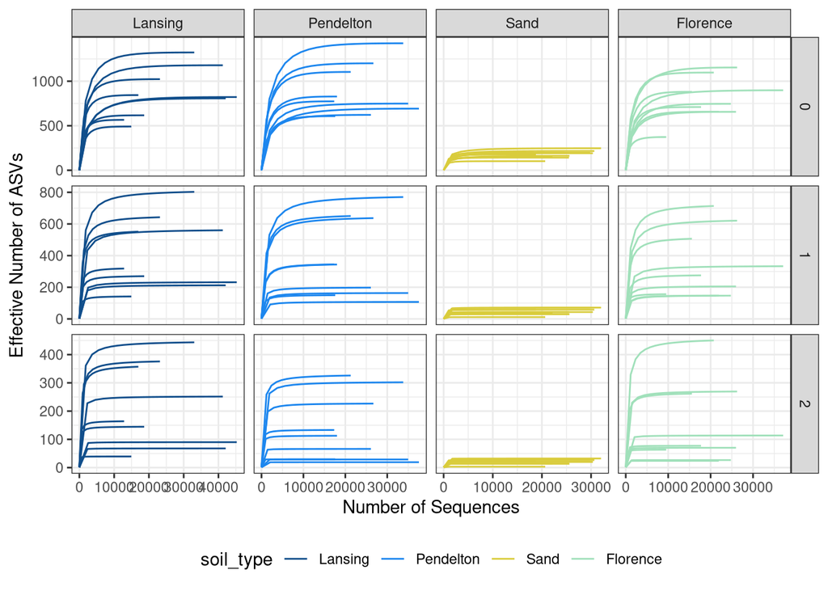

```r
# Manually plot rarefaction curves
iNEXT_manual_df %>%
  # Filter out rows that are calculated with actual sequences (no extrapolated)
  dplyr::filter(Method == "Rarefaction") %>%
  # Now, let's draw the plot!
  ggplot(aes(x = m, y = qD, color = soil_type, group = names)) +
  geom_line() +
  # Facet by station
  facet_grid(Order.q~soil_type, scales = "free") +
  scale_color_manual(values = soil_colors) +
  theme_bw() +
  labs(y = "Effective Number of ASVs", x = "Number of Sequences") +
  theme(legend.position = "bottom")
```

INTERPRETATION #1: In all the rarefaction curves, it seems like a plateau is reached. Under the q=0,1,2 conditions, this asymptote is reached. Especially for sand, it’s achieved extremely quickly. Sequencing depth appears to be adequate and analysis can proceed.

While the rarefaction curves from `ggiNEXT` agglomerated the data together, it was hard to see individual samples. Above, we can start to tease apart specific samples within each station, which can be done for any categorical variable.

# Statististical Testing

So, how do we actually quantify the changes in biodiversity that we may observe between the samples? That takes us into statistics!

**How to run the Shapiro-Wilk test?**

```r
# Test of the data is normal for the continuous value of salinity
shapiro.test(metadata_full_df$TC_percent)
```

```
##
##  Shapiro-Wilk normality test
##
## data:  metadata_full_df$TC_percent
## W = 0.82596, p-value = 5.578e-05
```

Ok! So, the test above has a p-value <0.05, indicating that we can reject the H₀, which will indicate that the data is **not normal**. Therefore, we need to use non-parametric statistical tests in the data.

*Is the simpson data normal?*

```r
### Now what about for richness?
obs_div_df <-
  iNEXT_manual_df %>%
  dplyr::filter(Method == "Observed")

# check it
glimpse(obs_div_df)
```

```
## Rows: 108
## Columns: 20
## $ names             <chr> "SRR12183139", "SRR12183139", "SRR12183139", "SRR121…
## $ m                 <dbl> 30668, 30668, 30668, 25606, 25606, 25606, 30370, 303…
## $ Method            <chr> "Observed", "Observed", "Observed", "Observed", "Obs…
## $ Order.q           <dbl> 0, 1, 2, 0, 1, 2, 0, 1, 2, 0, 1, 2, 0, 1, 2, 0, 1, 2…
## $ qD                <dbl> 216.00000, 58.47275, 26.48551, 162.00000, 29.51474, …
## $ qD.LCL            <dbl> 213.97124, 57.56689, 25.83473, 159.84713, 28.98437, …
## $ qD.UCL            <dbl> 218.02876, 59.37861, 27.13629, 164.15287, 30.04511, …
## $ SC                <dbl> 1, 1, 1, 1, 1, 1, 1, 1, 1, 1, 1, 1, 1, 1, 1, 1, 1, 1…
## $ SC.LCL            <dbl> 0.9999182, 0.9999182, 0.9999182, 0.9998780, 0.999878…
## $ SC.UCL            <dbl> 1, 1, 1, 1, 1, 1, 1, 1, 1, 1, 1, 1, 1, 1, 1, 1, 1, 1…
## $ scientific_name   <chr> "soil metagenome", "soil metagenome", "soil metageno…
## $ experiment_title  <chr> "Illumina MiSeq sequencing: 16S amplicon of CS sampl…
## $ soil_type         <fct> Sand, Sand, Sand, Sand, Sand, Sand, Sand, Sand, Sand…
## $ Sample_or_Control <lgl> TRUE, TRUE, TRUE, TRUE, TRUE, TRUE, TRUE, TRUE, TRUE…
## $ denoisedF         <dbl> 34565, 34565, 34565, 28298, 28298, 28298, 33520, 335…
## $ denoisedR         <dbl> 34534, 34534, 34534, 28313, 28313, 28313, 33560, 335…
## $ merged            <dbl> 34131, 34131, 34131, 27814, 27814, 27814, 32974, 329…
## $ nochim            <dbl> 32332, 32332, 32332, 25728, 25728, 25728, 30590, 305…
## $ num_ASVs          <dbl> 240, 240, 240, 170, 170, 170, 204, 204, 204, 767, 76…
## $ TC_percent        <dbl> 0.00, 0.00, 0.00, 0.00, 0.00, 0.00, 0.00, 0.00, 0.00…
```

```r
# Pull out unique data from the three fractions of samples
obs_whole_rich_df <-
  obs_div_df %>%
  dplyr::filter(Order.q == 2)

# Test of the data is normal for the continuous value of richness
shapiro.test(obs_whole_rich_df$qD)
```

```
##
##  Shapiro-Wilk normality test
##
## data:  obs_whole_rich_df$qD
## W = 0.81741, p-value = 3.682e-05
```

## Statistics in Microbial Ecology

Generally speaking, we tend to use non-parametric tests in microbial ecology. It’s safer to go this way. However, if there is a test performed to show that the data is normally distributed, then we can access the robustness of parametric tests!

| **Research Question** | **Parametric Test** | **Non-Parametric Test** |
| --- | --- | --- |
| Compare alpha diversity (2 groups) | t-test | Wilcoxon rank-sum test |
| Compare alpha diversity (more than 2 groups) | ANOVA | Kruskal-Wallis test |
| Correlate diversity with environmental data | Pearson correlation | Spearman correlation |
| Test differences in beta diversity | *Not applicable* (uses distance matrices) | PERMANOVA (non-parametric) |
| Model transformed taxon abundances | Linear regression, GLM | Rank-based regression |

**Takeaways about statistics**

- **Parametric statistics** use data values directly (means, variances) and are more powerful when assumptions (*e.g.,* normality, homoscedasticity) are met.
- **Non-parametric statistics** use ranks and are more powerful when there are violations of assumptions that are made in parametric statistics, making them a safer choice for skewed, sparse, or ordinal data, which is commonplace in microbial ecology.
- In microbial ecology, non-parametric methods are commonly used due to the nature of microbiome data (*e.g.,* zero-inflated, non-normal, compositional), but **parametric tests are absolutely valid** when assumptions are met or appropriate transformations are applied.

Choose your statistical approach based on the:

- Type and distribution of your data
- Question you’re asking
- Assumptions your data can reasonably meet

# Categorical Analysis: 2 or more groups

Carbon content is pulled from a chart in supplementary materials with the average total carbon in each soil type. It doesn’t differentiate b/w each sample so carbon content and soil type are 1:1 correlated in my metadata.

### Diversity by Station

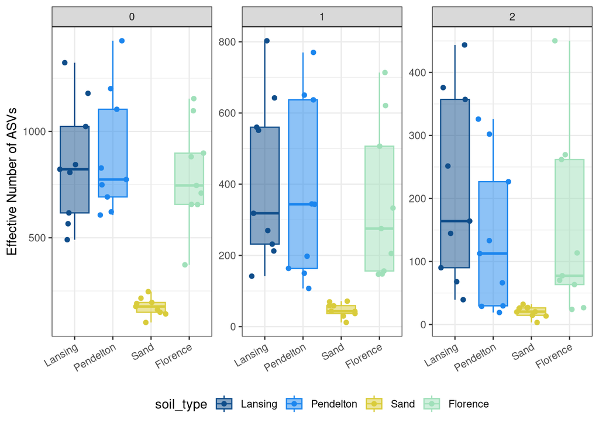

```r
# Plot boxplots by soil against diversity
obs_div_df %>%
  ggplot(aes(x = soil_type, y = qD, fill = soil_type,
             color = soil_type)) +
  facet_wrap(.~Order.q, scales = "free_y") +
  geom_jitter() +
  geom_boxplot(alpha = 0.5, outlier.shape = NA) +
  scale_color_manual(values = soil_colors) +
  scale_fill_manual(values = soil_colors) +
  labs(y = "Effective Number of ASVs") +
  theme_bw() +
  theme(legend.position = "bottom",
        axis.title.x = element_blank(),
        axis.text.x = element_text(angle = 30,
                                   hjust = 1,
                                   vjust = 1))
```

#### Statistically test Richness

```r
# Pull out richness data
obs_rich_df <-
  obs_div_df %>%
  dplyr::filter(Order.q == 0)

# Calculate the kruskal wallis
krusk_station_rich <-
  kruskal_test(qD ~ soil_type, data = obs_rich_df)

# Look at it
krusk_station_rich
```

```
## # A tibble: 1 × 6
##   .y.       n statistic    df        p method
## * <chr> <int>     <dbl> <int>    <dbl> <chr>
## 1 qD       36      19.8     3 0.000184 Kruskal-Wallis
```

```r
summary(krusk_station_rich)
```

```
##      .y.                  n        statistic           df          p
##  Length:1           Min.   :36   Min.   :19.83   Min.   :3   Min.   :0.000184
##  Class :character   1st Qu.:36   1st Qu.:19.83   1st Qu.:3   1st Qu.:0.000184
##  Mode  :character   Median :36   Median :19.83   Median :3   Median :0.000184
##                     Mean   :36   Mean   :19.83   Mean   :3   Mean   :0.000184
##                     3rd Qu.:36   3rd Qu.:19.83   3rd Qu.:3   3rd Qu.:0.000184
##                     Max.   :36   Max.   :19.83   Max.   :3   Max.   :0.000184
##     method
##  Length:1
##  Class :character
##  Mode  :character
##
##
##
```

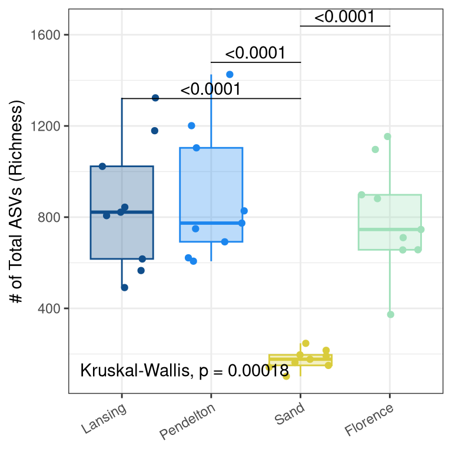

```r
# Richness by station
rich_ggboxplot <-
  ggboxplot(obs_rich_df, x = "soil_type", y = "qD",
          color = "soil_type", fill = "soil_type", alpha = 0.3,
          outlier.shape = NA) +
  # Add points
  geom_jitter(aes(color = soil_type)) +
  scale_color_manual(values = soil_colors) +
  scale_fill_manual(values = soil_colors) +
  labs(y = "# of Total ASVs (Richness)") +
  stat_compare_means(method = "kruskal.test", label.y = min(obs_rich_df$qD)) +
  geom_pwc(
    aes(group = soil_type), tip.length = 0, hide.ns = TRUE,
    method = "wilcox.test", label = "p.adj.format",
    p.adjust.method = "fdr", bracket.nudge.y = -0.08) +
  theme_bw() +
  theme(legend.position = "none",
        axis.title.x = element_blank(),
        axis.text.x = element_text(angle = 30,
                                   hjust = 1,
                                   vjust = 1))

rich_ggboxplot
```

### Shannon

```r
# Pull out shannon data
obs_shan_df <-
  obs_div_df %>%
  dplyr::filter(Order.q == 1)

# Calculate the kruskal wallis
krusk_station_shan <-
  kruskal_test(qD ~ soil_type, data = obs_shan_df)

# Look at it
krusk_station_shan
```

```
## # A tibble: 1 × 6
##   .y.       n statistic    df       p method
## * <chr> <int>     <dbl> <int>   <dbl> <chr>
## 1 qD       36      20.0     3 0.00017 Kruskal-Wallis
```

```r
summary(krusk_station_shan)
```

```
##      .y.                  n        statistic           df          p
##  Length:1           Min.   :36   Min.   :19.99   Min.   :3   Min.   :0.00017
##  Class :character   1st Qu.:36   1st Qu.:19.99   1st Qu.:3   1st Qu.:0.00017
##  Mode  :character   Median :36   Median :19.99   Median :3   Median :0.00017
##                     Mean   :36   Mean   :19.99   Mean   :3   Mean   :0.00017
##                     3rd Qu.:36   3rd Qu.:19.99   3rd Qu.:3   3rd Qu.:0.00017
##                     Max.   :36   Max.   :19.99   Max.   :3   Max.   :0.00017
##     method
##  Length:1
##  Class :character
##  Mode  :character
##
##
##
```

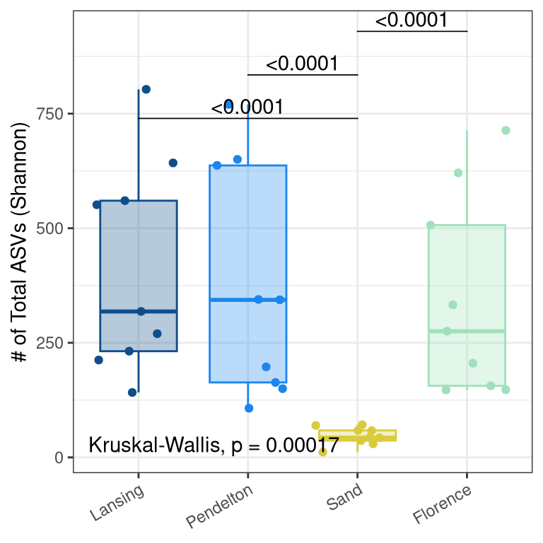

```r
# Richness by station
shan_ggboxplot <-
  ggboxplot(obs_shan_df, x = "soil_type", y = "qD",
          color = "soil_type", fill = "soil_type", alpha = 0.3,
          outlier.shape = NA) +
  # Add points
  geom_jitter(aes(color = soil_type)) +
  scale_color_manual(values = soil_colors) +
  scale_fill_manual(values = soil_colors) +
  labs(y = "# of Total ASVs (Shannon)") +
  stat_compare_means(method = "kruskal.test", label.y = min(obs_shan_df$qD)) +
  geom_pwc(
    aes(group = soil_type), tip.length = 0, hide.ns = TRUE,
    method = "wilcox.test", label = "p.adj.format",
    p.adjust.method = "fdr", bracket.nudge.y = -0.08) +
  theme_bw() +
  theme(legend.position = "none",
        axis.title.x = element_blank(),
        axis.text.x = element_text(angle = 30,
                                   hjust = 1,
                                   vjust = 1))

shan_ggboxplot
```